# Grocery

1. Cài đặt thư viện mlxtend và xlrd

Sau khi cài đặt, import các thư viện cần thiết: thư viện máy học (mlxtend)

```python
import pandas as pd
import seaborn as sns
import matplotlib.pyplot as plt
%matplotlib inline
from mlxtend.frequent_patterns import apriori
from mlxtend.frequent_patterns import association_rules
```

```python
with open('F:\DOWNLOAD\KHAI THAC DL\DATA\GCR.csv') as f:
    df = pd.read_csv(f)
```

Sau khi dữ liệu được đọc vào biến df, hiển thị một vài thông tin của biến này

```python
df.info()
```

```
<class 'pandas.core.frame.DataFrame'>
RangeIndex: 9834 entries, 0 to 9833
Data columns (total 4 columns):
 #   Column               Non-Null Count  Dtype
---  ------               --------------  -----
 0   citrus fruit         9834 non-null   object
 1   semi-finished bread  7675 non-null   object
 2   margarine            6032 non-null   object
 3   ready soups          4733 non-null   object
dtypes: object(4)
memory usage: 307.4+ KB
```

Xem thử 10 dòng đầu của dữ liệu

```python
df.head(10)
```

|  | citrus fruit | semi-finished bread | margarine | ready soups |
| --- | --- | --- | --- | --- |
| 0 | tropical fruit | yogurt | coffee | NaN |
| 1 | whole milk | NaN | NaN | NaN |
| 2 | pip fruit | yogurt | cream cheese | meat spreads |
| 3 | other vegetables | whole milk | condensed milk | long life bakery product |
| 4 | whole milk | butter | yogurt | rice |
| 5 | rolls/buns | NaN | NaN | NaN |
| 6 | other vegetables | UHT-milk | rolls/buns | bottled beer |
| 7 | potted plants | NaN | NaN | NaN |
| 8 | whole milk | cereals | NaN | NaN |
| 9 | tropical fruit | other vegetables | white bread | bottled water |

1. Xem số lượng giá trị rỗng của 4 thuộc tính

```python
total = df.isnull().sum().sort_values(ascending=False)
percent_1 = df.isnull().sum()/df.isnull().count()*100
percent_2 = (round(percent_1,1)).sort_values(ascending=False)
missing_data = pd.concat([total,percent_2], axis=1, keys=['Total', '%'])
missing_data.head(4)
```

|  | Total | % |
| --- | --- | --- |
| ready soups | 5101 | 51.9 |
| margarine | 3802 | 38.7 |
| semi-finished bread | 2159 | 22.0 |
| citrus fruit | 0 | 0.0 |

Từ bảng trên ta có thể thấy trừ thuộc tính 'citrus fruit', các thuộc tính còn lại đều bị rỗng khá nhiều. Cao nhất là 'ready soups' với 51,9% rỗng

Ta thực hiện xem xét thông tin thuộc tính 'ready soups'

```python
df['ready soups'].describe()
```

```
count           4733
unique           152
top       whole milk
freq             315
Name: ready soups, dtype: object
```

Từ trên ta thấy được giá trị có độ phổ biến trong thuộc tính 'ready soups' cao nhất là whole milk.

```python
common_value = 'whole milk'

for dataset in [df]:
    dataset['ready soups'] = dataset['ready soups'].fillna(common_value)
```

Do đó ta chọn giá trị whole milk điền vào các giá trị trống.

Thực hiện xem xét thông tin thuộc tính 'margarine'

```python
df['margarine'].describe()
```

```
count           6032
unique           155
top       whole milk
freq             506
Name: margarine, dtype: object
```

Từ trên ta thấy được giá trị có độ phổ biến trong thuộc tính 'margarine' cao nhất là whole milk.

```python
common_value = 'whole milk'

for dataset in [df]:
    dataset['margarine'] = dataset['margarine'].fillna(common_value)
```

Do đó ta chọn giá trị whole milk điền vào các giá trị trống.

Thực hiện xem xét thông tin thuộc tính 'semi-finished bread'

```python
df['semi-finished bread'].describe()
```

```
count           7675
unique           151
top       whole milk
freq             654
Name: semi-finished bread, dtype: object
```

Từ trên ta thấy được giá trị có độ phổ biến trong thuộc tính 'semi-finished bread' cao nhất là whole milk.

```python
common_value = 'whole milk'

for dataset in [df]:
    dataset['semi-finished bread'] = dataset['semi-finished bread'].fillna(common_value)
```

Do đó ta chọn giá trị whole milk điền vào các giá trị trống.

1. Thống kê dòng dữ liệu theo citrus fruit

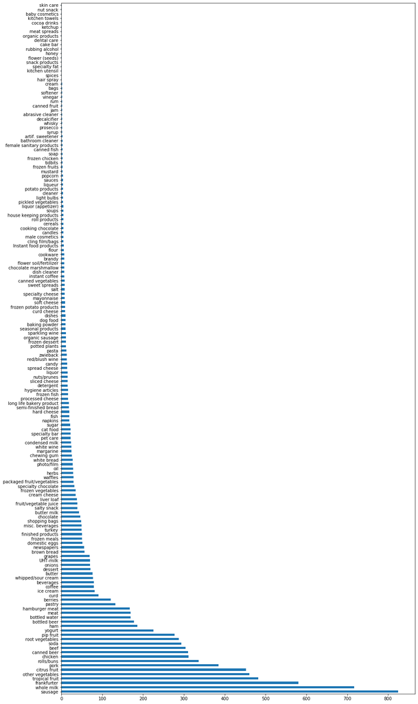

```python
df['citrus fruit'].value_counts().plot(kind='barh', figsize=(15,30))
```

Kết quả được hiển thị như hình trên.

1. Chỉ xét các thực phẩm là xúc xích và nhóm dữ liệu theo semi-finished bread, margarine, ready soups

```python
basket = df[df['citrus fruit'] == "sausage"].groupby(['semi-finished bread', 'margarine'])['ready soups']
```

Chuyển đổi dữ liệu về dạng hot encoding

```python
basket = basket.sum().unstack().reset_index().fillna(0).set_index(0)
```

[output not shown]

```python
basket.head(10)
```

[output not shown]